# PFQC Presentation Nov 2019

- This presentation is not going to be following a specific theme as such.
- It is going to be a collection of random thoughts.
- This is not going to be too technical, and aimed at generic audience.

### Ergodicity

- **Simple Question**
  - You start with a total capital of 1000 dollars. You are offered a gamble on a fair coin toss, if it lands heads you pay 100 dollars and if it lands tails you win 110 dollars.
- **Assumptions**
  - You are allowed to play this gamble multiple times.
  - You returns are always scaled by your capital. If your capital grows to 2000 dollars, you will pay 200 dollars on tails and win 220 dollars on heads.
- *How many of you would accept the gamble and why ?*
- Clearly it has a positive expected value, so one should be foolish not to accept !!? May not be true.
- How does you capital change over time ?
- The mean return from each round is 0.005 or 0.5%.
- The variance of returns would be 0.011025. $$\partial{S_t} = \mu S_{t} \partial{dt} + \sigma S_{t} \partial {W_{t}}$$ $$\log\frac{S_{t}}{S_{0}} = (\mu - \frac{\sigma^2}{2})t + \sigma \partial{W_{t}}$$
- After time t, mean return is going to be $(\mu - \frac{\sigma^2}{2})*t$ and **not** $\mu*t$. We need to account for the **risk** in the trade.

```python
import pandas as pd
import numpy as np

df = pd.DataFrame({'returns':[-0.10, 0.11], 'prob':[0.5, 0.5]})
print(df)
mean = np.round(np.sum(df['returns']*df['prob']),5)
print('----------------------------')
print('Mean')
print(mean)
var = np.round(np.sum((df['returns']**2)*df['prob']),5)-mean*mean
print('----------------------------')
print('VaR')
print(var)
print('----------------------------')
print('Mean - Var*0.5')
print(mean-var*0.5)
```

```
   returns  prob
0    -0.10   0.5
1     0.11   0.5
----------------------------
Mean
0.005
----------------------------
VaR
0.011025
----------------------------
Mean - Var*0.5
-0.0005124999999999999
```

- $\mu*t$ can be considered as an ensemble average i.e average when things happen simultaneously, and $(\mu - \frac{\sigma^2}{2})*t$ can be considered as time average which in case of gamble the **true expected value**.
- 100 people playing roulette at once is different from one person playing 100 rounds of roulette.
- When these two are equal for a variable, then it is said to have the property of ergodicity.
- **Ergodicity**: *The expectation value of the observable is a constant (independent of time), and the finite-time average of the observable converges to this constant with probability one as the averaging time tends to infinity.*
- **Reference**: Evaluating gambles using dynamics by Ole Peters, Murray Gell-Mann

### Jensen's inequality

- Currently lets assume Dollar-Rupee exchange rate is 1.
- In 6 months, dollar against Rupee has 50% probability of being 1.2 and 50% probability of being 0.8.
- From a Dollar perspective
  - Expected Value : 0.5 x (1.2)+ 0.5 x (0.8) = 1
- From a Rupee perspective
  - Expected Value : 0.5 x (1/1.2) + 0.5 x (1/0.8) = 1.042

**But wait! shouldn't this be 1?**

- This follows from Jensen's inequality which $$E[f(x)] \neq f[E(x)]$$
- You should be careful while changing the domain and comparing.
- In reality when Dollar-Rupee increases by 20% to 1.2, Rupee-Dollar would decrease by 20% to 0.80 and not to (1/1.2) 0.83.
- **Reference**: Solution to the Siegel Paradox KAM HON CHU

### Convergence

- At work we once ordered Baos from Wow Bao Restaurant for lunch.
- Apart from the facilities team, none of the employees knew the number of Baos being ordered. We were around 400 employees. (So one could kind of guess.)
- A slack channel started trying to predicted the number of baos ordered and soon a two sided **liquid** market followed.
- At the end of the day actual number would be revealed.
- I thought each would eat around 2.5 so they would probably ordered 1000.
- At one point of the day the market was 2400 bid @ 2500 offer. So I sold.
- After some point, the market was 1000 bid @ 1100 offer and I bought back for a profit.
- Finally market was 1500 bid @ 1600 offered. But the actual number of orders was 1800. It seems there were 450 employees and they assumed 4 per each.
- Market did not settle close to the actual value.
- I made money even though I was fundamentally wrong.
- This is not a very abstract example, in agriculture futures market there were instances when future did not converge to cash price at expiration.
- **Reference**: Understanding the Non-Convergence of Agricultural Futures via Stochastic Storage Costs and Timing Options Kevin Guo Tim Leung
- So how do you make money in the market ?
  - Do you need to be right on fundamentals ? **OR**
  - Do you need to be right on what the market **thinks** fundamentals are ?

### Risk Vs Uncertainty

- What is the different between risk and uncertainty ?
- All outcomes are known and the probabilities of the outcomes are known. Its a rule based game.
- All outcomes are known but the probabilities of the outcomes are not known.
- Neither all outcomes are known nor the probabilities associated with them are known.
- Statistics apply well in the first case and we can compute **risk**.
- But in last two scenarios, we should be careful in applying mathematical tools.
- Markets are complex adaptive systems.
- Does dog catching a frisbee know newtonian mechanics ?
- Heuristics work in 2-3 scenarios, coming up with good heuristics is a skill.
- **Reference**: Simple Heuristics by Gerd Gigerenzer

#### Side Note

- It is important to remember the dynamic nature of markets, there would be certain things that may not be captured in you analysis. Some techniques from Machine Learning book by Marcos Lopez.
  - **Triple Barrier Method**
  - **Fractional Differentiation**

### Market Efficiency

- In Kerela, a fishing society in South India, following were the proceedings
  - Farmers went fishing in the morning.
  - In the evening, after the catch they had to choose a beach to go to. In order to sell their fish.
  - If lot of Farmers choose the same beach, average fish prices on that day would be lower.
    - Below is the time series of fish prices in different regions in Kerala.

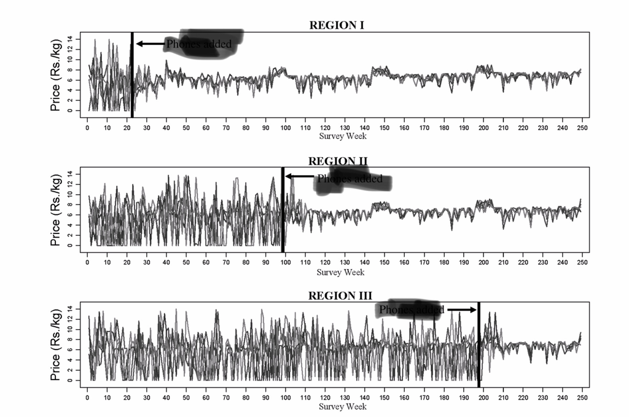

```python
from IPython.display import Image
Image('kerela_fishing.jpg')
```

- What changed ?
- Phones were introduced and farmers were able to co-ordinate better.
- This is another classical example where communication / information technology makes markets more efficient.
- How do quantitative traders make money in markets ?
  - Markets are complex, adaptive information processing systems. I tend to think of them as big marketplace for risk and people pay a premium to lay off risk.
    - Ability to take on risk intelligently.
    - Different participants - Hedgers, Speculators and Market Makers and different incentives and operate in different time horizons.
  - New inefficiencies can arise in markets. example: new regulations, new policies etc.
  - Transferring liquidity across assets. Glue that hold markets together. Liquidity and price impact propagation. Single stock example: Microsoft cannot be efficiently priced without pricing cross-sectional stocks. Quantitative trading opportunity arises as dislocation to cross-sectional prices.
  - Ability to study richer datasets and their impact on information security prices.
  - According to me generating new trading strategies is a creative endeavor.

### Thank You

- I am interested in setting up a Quant Meetup Group in Chicago. If anyone is interested in the same, or have other similar ideas kindly get in touch with me. Sai Poddutur saikrishna.3490@gmail.com